# projekt2

Kamil Kućma

11 01 2022

Wykresy i ich analiza będzie dotyczyć danych ze zbioru gapminder wbudowanego w R, powiększonego o kilka dodatkowych informacji, pobranych ze strony https://www.gapminder.org/data/ w postaci plików .csv i dołączonych do orginalnych danych. Same wykresy skupią się na zestawianiu między sobą kontynentów na różnych płaszczyznach.

Pobieram biblioteki i przypisuję dane do zmiennej.

```r
library(tidyr)
library(gapminder)
library(tidyverse)
```

```r
library(dplyr)
library(ggplot2)
library(CGPfunctions)
dane<-gapminder
```

Pierwszym zagadnieniem będzie PKB per capita.

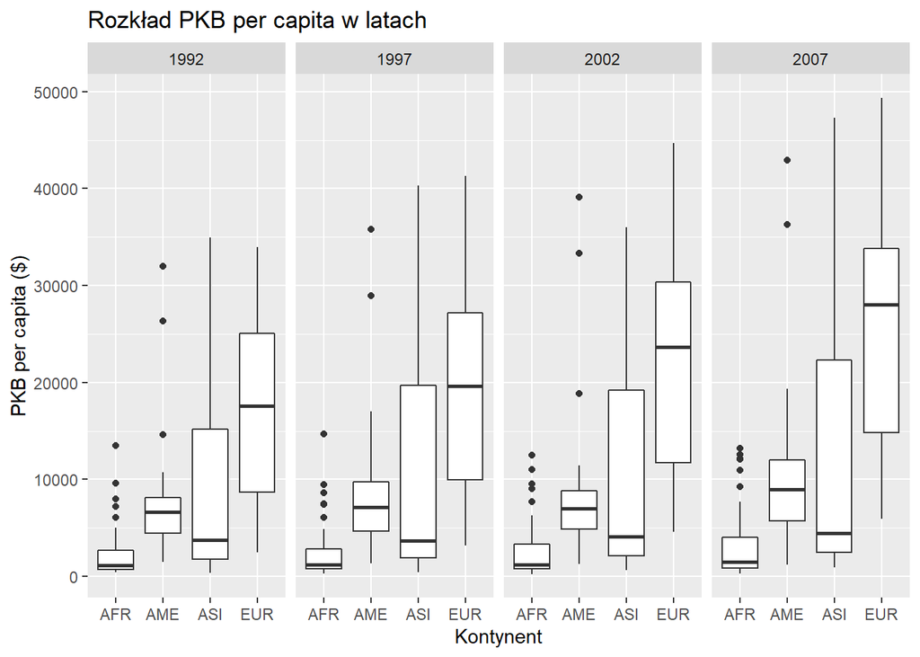

```r
dane2<-dane%>%
  mutate(continent=toupper(substr(x = continent, start = 1, stop = 3)))  # skracam nazwy kontynentów, żeby nie nachodziły na siebie na wykresie

dane2%>%
  filter(continent!="OCE", country!="KUW", year %in% c("1992","1997","2002","2007"))%>% # oceanię w danych reprezentują tylko 2 kraje więc odrzucam
  ggplot() +
    geom_boxplot(mapping = aes(x = continent, y = gdpPercap)) + # wykres pudełkowy
    labs (title="Rozkład PKB per capita w latach",  # ustawianie tytułu i podpisu osi
        x = "Kontynent",
        y = "PKB per capita ($)") +
    facet_wrap(~as.factor(year), nrow=1) # dzielę główny wykres na podgrupy na podstawie zmiennej rok
```

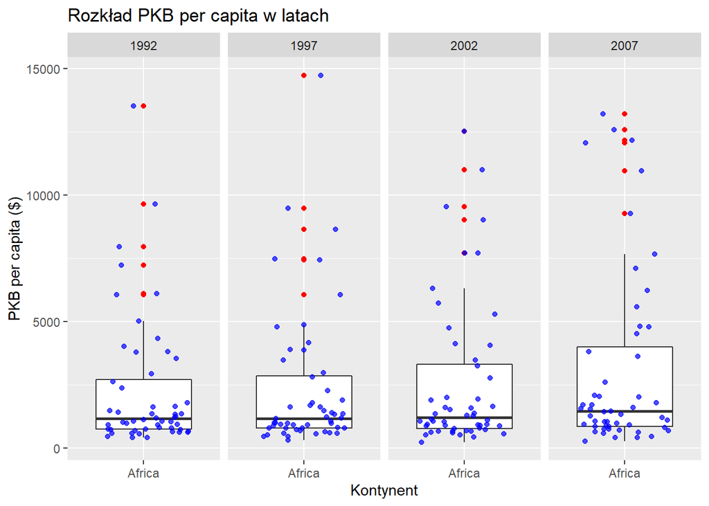

```r
dane%>%
  filter(continent=="Africa", year %in% c("1992","1997","2002","2007"))%>%
  ggplot() +
    geom_boxplot(mapping = aes(x = continent, y = gdpPercap), outlier.colour = "red") +
    geom_jitter(mapping = aes(x = continent, y = gdpPercap), width = 0.35, color = "blue", alpha=0.7) + # wykres punktowy
    labs (title="Rozkład PKB per capita w latach",
        x = "Kontynent",
        y = "PKB per capita ($)") +
    facet_wrap(~as.factor(year), nrow=1)
```

Kolejny wykres będzie dotyczył tego, który kontynent (w przeliczeniu na osobę) najbardziej szkodzi(ł) ziemii, w postaci produkcji największych ilości CO2.

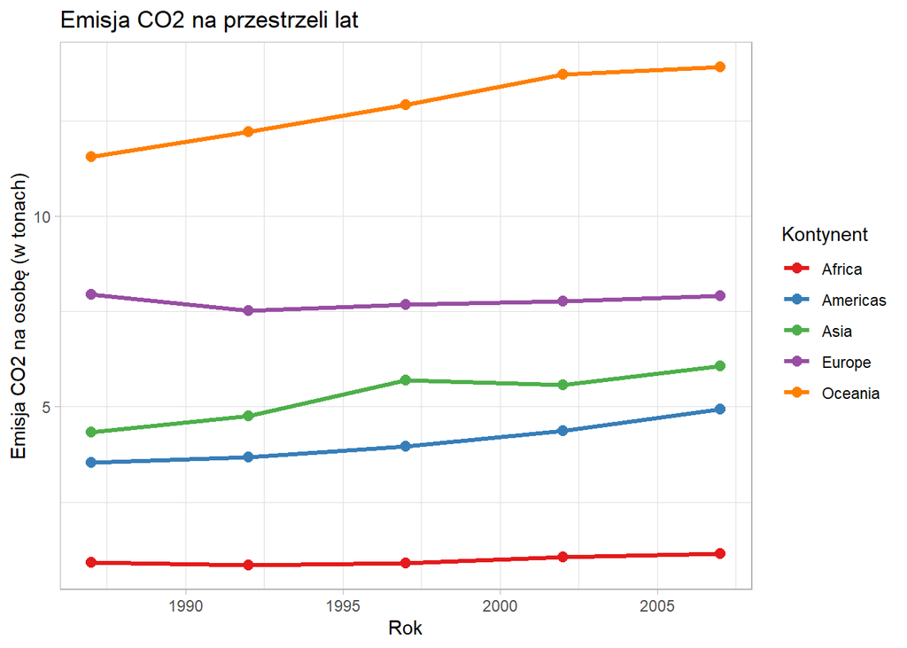

```r
dane_co2<-read.csv(file = "D:/R/co2.csv", sep=",")  # wczytuję dane
dane_co2<-dane_co2 %>%
  select(ď.żcountry, X1987, X1992, X1997, X2002, X2007)%>%  # wybieram konkretne lata i zmieniam nazwy kolumn
  rename(
      country = ď.żcountry,
      '1987' = X1987,
      '1992' = X1992,
      '1997' = X1997,
      '2002' = X2002,
      '2007' = X2007)
dane_co2<-dane_co2 %>%
  gather("year", "co2_emission", -1, na.rm = TRUE)    # przekształcam dane do takiej postaci jak te z gapmindera
dane_co2$year <- as.integer(dane_co2$year)

daneCO2<-dane %>%
  filter(year>=1987)
daneCO2<-inner_join(daneCO2, dane_co2, by = c("country", "year") ) # łączę dane z gapmindera i te pobrane

daneCO2%>%
  group_by(continent, year)%>%
  summarize(mean_co2_emission=mean(co2_emission), .groups="keep")%>%
  ggplot(aes(x = year, y = mean_co2_emission, col = continent)) + # podsumowuje dane po  średniej i ją przedstawiam na osi oy
  geom_line(size = 1.2) +  # wykres liniowy
  geom_point(size = 2.4)+ # wykres punktowy
  labs (title="Emisja CO2 na przestrzeli lat",
      x = "Rok",
      y = "Emisja CO2 na osobę (w tonach)",
      color = "Kontynent") +
  theme_light()+  # ustawiam białe tło z szarymi liniami
  scale_color_brewer(palette = "Set1")  # chce dobrze odróżniać kolory więc wybieram paletę i różnymi od siebie kolorami
```

Wykres przedstawia średnią emisję CO2 na osobę (w tonach) na danych kontynentach. Biorąc pod uwagę wcześniejsze wykresy, to ułożenie krajów w danej kolejności nie specjalnie dziwi. Głowne źródła emisji dwutlenku węgla to spalanie paliw w elektrowniach, produkcja przemysłowa oraz transport, co za tym idzie, wysoką emisję CO2 będą mieć te kraje, które są wysoko rozwiniętę i mają rozwnięty przemysł, Dużą różnicę pomiędzy Oceanią a Europą może powodować fakt, że w średnią wchodzą jedynie Autstralia i Nowa Zelandia, czyli dwa dobrze rozwnięte kraje, gdzie w Europie, szczególnie we wcześniejszych latach, tę średnią zaniżają np. takie kraje jak Rumunia. Choć wykres przedstawia ciągłe, to dane pochodzą z pięciu konkretnych lat, dlatego też zostały one oznaczone konkretnymi punktami, które owa ciągła łączy.

Kolejną kwestią będzie sprawdzenie możliwości ludności na danych kontynentach co do dostępu do Internetu i jego wzrostu (może spadku?) w ciągu 5 lat.

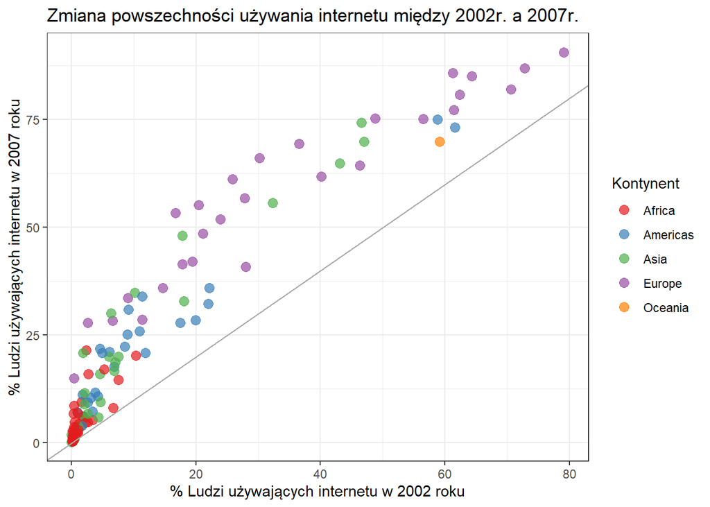

```r
dane_internet<-read.csv(file = "D:/R/internet_users.csv", sep=",")
dane_internet<-dane_internet %>%
  select(ď.żcountry, X2002, X2007)%>%
  rename(
      country = ď.żcountry,
      '2002' = X2002,
      '2007' = X2007)
dane_internet<-dane_internet %>%
  gather("year", "internetUsersPrc", -1, na.rm = TRUE)
dane_internet$year <- as.integer(dane_internet$year)

daneInternet<-dane %>%
  filter(year %in% c('2002', '2007'))
daneInternet<-inner_join(daneInternet, dane_internet, by = c("country", "year"))

daneInternet %>%
  select(country, year, internetUsersPrc, continent) %>%
  spread(year, internetUsersPrc) %>% # zmieniam postac danych
  rename(internetUsersPrc_2002 = "2002", internetUsersPrc_2007 = "2007") %>%
  ggplot() +
    geom_point(mapping = aes(x = internetUsersPrc_2002, y = internetUsersPrc_2007, col = continent), size = 3, alpha = 0.7, na.rm = TRUE) +
    geom_abline(slope = 1, intercept = 0, color = "darkgrey") +  # wykres prostej
    labs (title = "Zmiana powszechności używania internetu między 2002r. a 2007r.",
         x = "% Ludzi używających internetu w 2002 roku",
         y = "% Ludzi używających internetu w 2007 roku",
         color = "Kontynent") +
    theme_bw()+
    scale_color_brewer(palette = "Set1")
```

Wykres przedstawia zmianę odsetka ludzi korzystających z internetu z podziałem na konkretne kontynenty. Każda kropka oznacza dane z kraju z konkretnego kontynentu. Dodana została pomocnicza krzywa y=x, która pomaga w interpretacji - kraje które znajdują się poniżej krzywej, mają zmniejszony odsetek ludzi korzystających z wykresu, a te, które są ponad nią, mają ten odsetek coraz większy Widać przy tym również siłę zmian, im punkt znajduje się dalej od linii, tym większa zmiana nastąpiła. W przypadku danych o użytkownikach internetu, nic dziwnego, że w żadnym przypadku ta wartość nie zmalała. Można zauważyć, że w tym aspekcie w przeciągu 5 lat największe postępy zrobiły kraje Europy i Azji. Blisko punktu 0,0 znajduje się duża część krajów, głównie afrykańskich, co oznacza, że w przeciągu tych 5 lat, albo wciąż nie rozpoczęły szeroko pojętego procesu cyfryzacji, albo dotyczył on bardzo niewielkiego odsetka ludności.

Kolejna część pokaże informacje odnośnie odsetku pracujących ludzi w młodym wieku (15-24 lat)

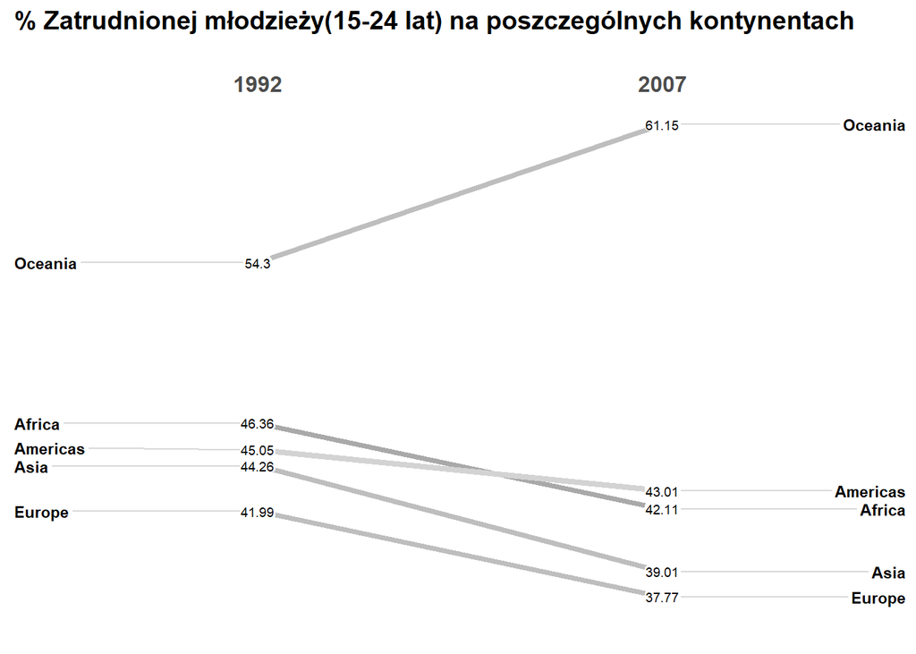

```r
dane_zatrudnienie<-read.csv(file = "D:/R/aged_15_24_employment_rate%.csv", sep=",")
dane_zatrudnienie<-dane_zatrudnienie %>%
  select(ď.żcountry, X1992, X2007)%>%
  rename(
      country = ď.żcountry,
      '1992' = X1992,
      '2007' = X2007)
dane_zatrudnienie<-dane_zatrudnienie %>%
  gather("year", "x15_24aged_employmentPrc", -1, na.rm = TRUE)
dane_zatrudnienie$year <- as.integer(dane_zatrudnienie$year)

daneZatrudnienie<-dane%>%
  filter(year %in% c("1992", "2007"))
daneZatrudnienie<-inner_join(daneZatrudnienie, dane_zatrudnienie, by = c("country", "year"))

daneZatrudnienie%>%
  mutate(year = factor(year, ordered = T)) %>%
  group_by(year, continent)%>%
  filter(year %in% c('1992', '2007'))%>%
  summarize(mean_emp=round(mean(x15_24aged_employmentPrc), 2), .groups = 'keep')%>%
  as.data.frame() %>%  # slopegraph potrzebuje danych z postaci dataframea
  newggslopegraph(Times = year,
                  Measurement = mean_emp,
                  Grouping = continent,
                  Title = "% Zatrudnionej młodzieży(15-24 lat) na poszczególnych kontynentach",
                  SubTitle = "",
                  Caption = "",
                  LineThickness = 1.5,
                  LineColor = c("darkgrey", "lightgrey", rep("grey", 3))
                  )
```

Wyniki można interpretować na różne sposoby, głównie ze względu na to, że najmniejsze i największe wartości należą do dwóch najlepiej rozwiniętych kontynentów. Z jednej strony, niski % pracujących w młodym wieku może świadczyć o tym, że wciąż się edukują, a więc dostęp do edukacji i jej jakość stoi na dobrym poziomie. Z drugiej strony, może od też świadczyć o wysokim bezrobociu Wśród młodych i problemach ze znalezieniem pracy. Z trzeciej strony, najwyższy odsetek pojawia się w najuboższych krajach, co może świadczyć o tym, że od najmłodszych lat wszyscy muszą pracować, aby przeżyć. Z czwartej strony należy wziąć pod uwagę wiek w którym zazwyczaj kończy się edukację oraz % osób udających się na studia. Tak też przykładowo, w Australii ( https://www.acara.edu.au/ ), edukację kończy się szybciej niż w Polsce, a także stosunkowo niewielki % młodzieży udaje się na studia wyższe, dlatego też może to wpływać, wraz z dużą liczbą miejsc pracy, na tak wysoki wynik Oceanii (gdzie Australia stanowi jeden z dwóch krajów objętych w danych)

Teraz zajmijmy się zróżnicowaniem oczekiwanej długości życia na różnych kontynentach

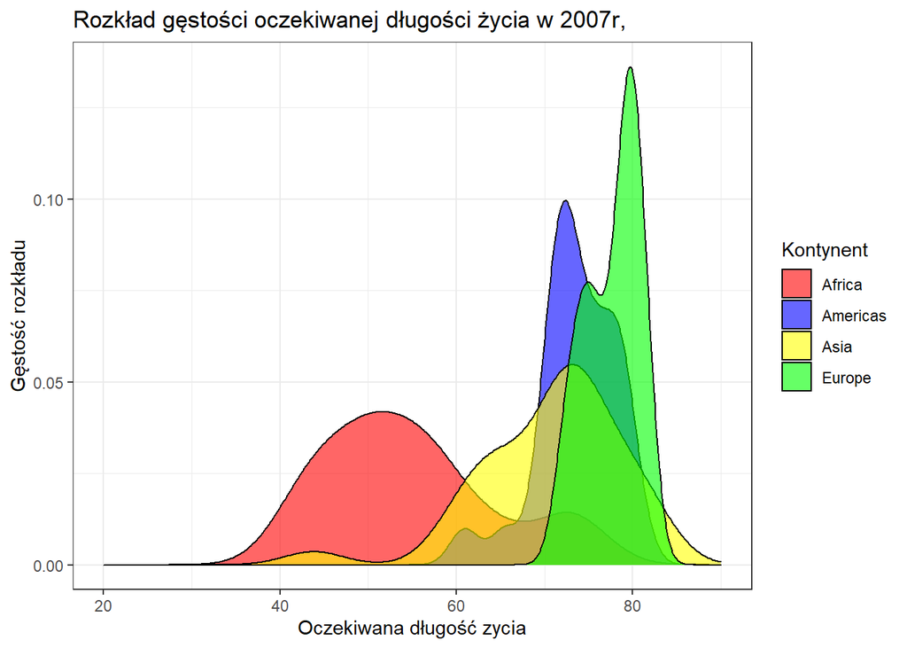

```r
dane %>%
  filter(continent!='Oceania', year=='2007')%>%
  ggplot() +
    geom_density(aes(x = lifeExp, fill = continent), alpha = 0.6) +  # wykres gęstości
    xlim(c(20, 90))+
    labs(
      title = "Rozkład gęstości oczekiwanej długości życia w 2007r,",
      x = "Oczekiwana długość zycia",
      y = "Gęstość rozkładu",
      fill = "Kontynent") +
      theme_bw()+
    scale_fill_manual(values = c("red","blue","yellow", "green"))
```

Z wykresu można zauważyć, że również pod tym względem Europa przoduje. Próżno szukać w niej krajów, które w 2007r. miały oczekiwaną długość życia istotnie mniejszą od 70, w najczęściej miała ona wartość na poziomie 75-80. Pod tym względem również dobrze wyglądają Ameryki, choć najczęściej oczekiwana wartość była o kilka lat niższa oraz zdarzały się kraje ze sporo niższą 60-70 wartością oczekiwanej długości życia. Azja pod tym względem jest mocno zróżnicowana - zdarzają się kraje z bardzo niską wartością, ale również z bardzo wysoką oczekiwaną długością życia. Najgorzej prezentuje się Afryka - rzadko kiedy oczekiwana długość życia przekracza 60 lat, najczęsciej ma ona wartość około 50 lat. Z wykresu odrzuciłem Oceanię - tylko dwie wartości stanowiły by wykres, który nie oddawałby prawdziwych informacji, oraz popsułby czytelność wykresu ( skala gęstości zwiększyła by się do +- 0,5).

Kolejny wykres dotyczyć będzie już konkretnego kontynentu (czy też dwóch, ale w danych ujętych razem) i jego krajów, a mianowicie, udziały procentowego lasów w ich całkowitej powierzchni.

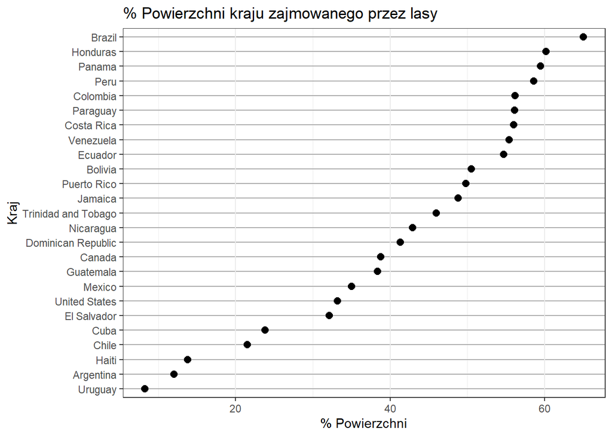

```r
dane_zalesienie<-read.csv(file = "D:/R/forest_coverage_percent.csv", sep=",")
dane_zalesienie<-dane_zalesienie %>%
  select(ď.żcountry, X2002)%>%
  rename( country = ď.żcountry, '2002' = X2002 )
dane_zalesienie<-dane_zalesienie %>%
  gather("year", "forest_prc", -1, na.rm = TRUE)
dane_zalesienie$year <- as.integer(dane_zalesienie$year)

daneZalesienie<-dane%>%
  filter(year=='2002')
daneZalesienie<-inner_join(daneZalesienie, dane_zalesienie, by = c("country", "year"))

daneZalesienie %>%
  filter(continent =="Americas", year == '2002') %>%
  ggplot(aes(y = reorder(country, forest_prc), x = forest_prc),
  fill = continent) +
  geom_point(size = 2.5, col = "black") +
  theme(panel.grid.major.y = element_line(colour = "darkgrey"))+
  labs(title = "% Powierzchni kraju zajmowanego przez lasy",
      x = '% Powierzchni',
      y = 'Kraj')
```

Z wykresu można zauważyć, że w ramach krajów obu Ameryk, zróżnicowanie w udziałach lasów w całych powierzchniach krajów jest bardzo duże. Największą część kraju, lasy stanowią w Brazylii, które stanowią ponad 60% powierzchni kraju, a najmniejszą w Urugwaju (niecałe 10% powierzchnii). Poza kilkoma krajami, wszystkie mają tych lasów przynjamniej 30% swojej powierzchni, a kilka krajów z czołówki zestawienia, ma do siebie bardzo zbliżone wartości.

Ostatnia część będzie dotyczyć wskaźnika WHR (World Happiness Raport) i jego powiązania z PKB i oczekiwaną długością życia.

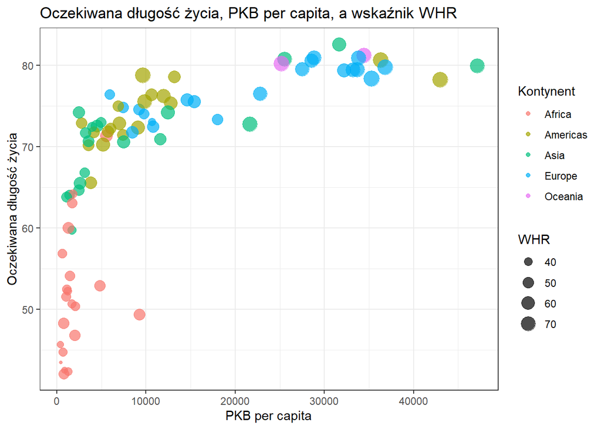

```r
dane_whr<-read.csv(file = "D:/R/whr.csv", sep=",")
dane_whr<-dane_whr %>%
  select(ď.żcountry, X2007)%>%
  rename(country = ď.żcountry, '2007' = X2007)
dane_whr<-dane_whr %>%
  gather("year", "whr", -1, na.rm = TRUE)
dane_whr$year <- as.integer(dane_whr$year)  # wskaznik zadowolenia

daneWhr<-dane %>%
  filter(year==2007)
daneWhr<-inner_join(daneWhr, dane_whr, by = c("country", "year"))

daneWhr %>%
  ggplot( aes(gdpPercap, lifeExp, size = whr, color=continent)) +
  geom_point(alpha = 0.7) +
  theme_bw() +
  labs(title = "Oczekiwana długość życia, PKB per capita, a wskaźnik WHR",
       x="PKB per capita",
       y="Oczekiwana długość życia",
       color="Kontynent",
       size="WHR")
```

Wykres uwzględnia aż cztery dane, na osiach oczekiwaną długość życia i PKB per capita, wielkość punktów oznacza wartość wskaźnika WHR - world happiness report, a kolor oznacza poszczególne kontynenty. Choć widać pewną zaleźność między PKB per capita a oczekiwaną długością życia, to nie jest ona silna, ludzie we wszystkich bogatych państwach żyją długo, a ci co żyją najkrócej, pochodzą z najbiedniejszych krajów, ale jednocześnie ludzie w wielu biednych krajach żyją prawie tak samo długo jak ci w najbogatszych. Pod tym względem negatywnie wyróżnia się ponownie Afryka, ale o tym już było. Warto zauważyć zależność, między PKB per capita i oczekiwaną długością życia a wskaźnikiem WHR, tam gdzie państwa są najbogatsze, a ludzie żyją najdłużej, tam ten wskaźnik z reguły jest najwyższy. Z racji iż nie opiera się on na twardych danych, tylko na opinii ludzi (odpowiadają pytanie, w skali 1-10 jak bardzo czują się szczęśliwi), można zauważyć że ludzie z Ameryk są bardziej zadowoleni z życia od tych z innych kontynentów o podobnych warunkach. Zapewne wynika to z podejścia kulturowego.